# EPO/Hepcidin analysis

# Number of observations with EPO and hepcidin values at baseline and pre-op

In the ITT sample (n = 474), EPO (mIU/mL) was measured in 421 patients at baseline and 392 patients prior to their operation but after the intervention was administered (354 patients had EPO measured at both time points and 15 had it measured at neither).

Hepcidin (ng/mL) was measured in 368 patients at baseline and 369 patients prior to their operation but after the intervention was administered (295 patients had EPO measured at both time points and 32 had it measured at neither).

# Impact of iron (ITT) on EPO and hepcidin values

**Table: Distribution of EPO and hepcidin by study arm**

| Variable | Observations | Total | Control | Active |
| --- | --- | --- | --- | --- |
| Baseline EPO (mIU/mL) | 421 | 27 [19, 39.9] | 27.2 [18.4, 38.7] | 26.8 [20.3, 41.1] |
| Baseline EPO (log10(mIU/mL)) | 421 | 1.4 [1.3, 1.6] | 1.4 [1.3, 1.6] | 1.4 [1.3, 1.6] |
| Pre-op EPO (mIU/mL) | 392 | 20.5 [15.2, 29.9] | 23.8 [16.2, 37.6] | 19 [14.1, 24.7] |
| Pre-op EPO (log10(mIU/mL)) | 392 | 1.3 [1.2, 1.5] | 1.4 [1.2, 1.6] | 1.3 [1.1, 1.4] |
| Change in EPO (mmol/L) | 354 | -4.9 [-13.1, 0.9] | -2 [-10.7, 3.5] | -7.7 [-17.3, -3.1] |
| Baseline hepcidin (ng/mL) | 368 | 9.8 [2.6, 21.8] | 9.6 [2.9, 21] | 10.1 [1.5, 22.3] |
| Baseline hepcidin (ng/mL) | 368 | 1 [0.4, 1.3] | 1 [0.5, 1.3] | 1 [0.2, 1.3] |
| Pre-op hepcidin (ng/mL) | 369 | 18.8 [5, 39.5] | 9 [2.4, 21] | 33.4 [15.1, 53.2] |
| Pre-op hepcidin (ng/mL) | 369 | 1.3 [0.7, 1.6] | 1 [0.4, 1.3] | 1.5 [1.2, 1.7] |
| Change in hepcidin (ng/mL) | 295 | 4.4 [-2.1, 18.5] | -0.2 [-7.3, 3.4] | 18.6 [5.9, 33.7] |

*Note: values are medians[IQR] or n(%)*

**Figure: Distributions of baseline and pre-operative EPO values (mIU/mL) by study arm.**

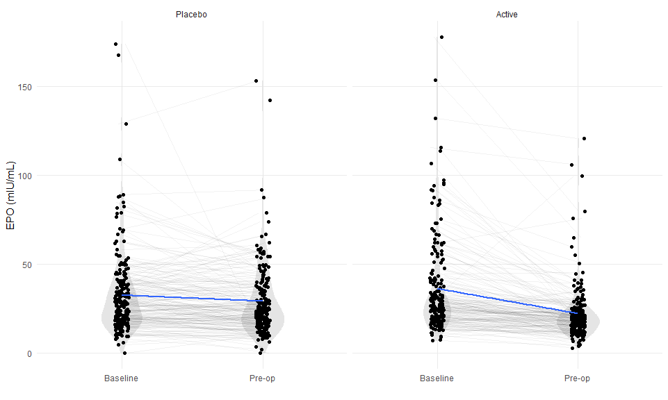

Baseline adjusted pre-operative EPO levels were 7.53 mIU/mL lower in the iron arm vs the placebo arm (-7.53 (-10.44 to -4.61); p = 0).

**Table: Effect of iron on EPO levels (mIU/mL) estimated by linear regression with adjustment for baseline EPO**

|  | epo preop miuml |  |  |
| --- | --- | --- | --- |
| Predictors | Estimates | CI | p |
| (Intercept) | 29.36 | 27.35 – 31.37 | **<0.001** |
| group [Active] | -7.53 | -10.45 – -4.60 | **<0.001** |
| mc(epo_bl_miuml) | 0.45 | 0.39 – 0.50 | **<0.001** |
| Observations | 354 |  |  |
| R<sup>2</sup> / R<sup>2</sup> adjusted | 0.403 / 0.400 |  |  |

**Figure: Distributions of baseline and pre-operative hepcidin values (ng/mL) by study arm.**

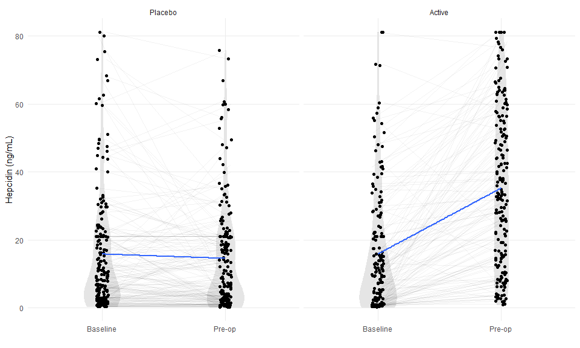

Pre-operative hepcidin levels were 22.7 ng/mL higher in the iron arm vs the placebo arm (22.7 (19.08 to 26.32); p = 0).

**Table: Effect of iron on hepcidin levels (ng/mL) estimated by linear regression with adjustment for baseline hepcidin**

|  | hepc preop ngml |  |  |
| --- | --- | --- | --- |
| Predictors | Estimates | CI | p |
| (Intercept) | 13.29 | 10.84 – 15.74 | **<0.001** |
| group [Active] | 22.70 | 19.06 – 26.33 | **<0.001** |
| mc(hepc_bl_ngml) | 0.61 | 0.51 – 0.72 | **<0.001** |
| Observations | 295 |  |  |
| R<sup>2</sup> / R<sup>2</sup> adjusted | 0.493 / 0.490 |  |  |

# Low hepcidin and pre-op Hb

*In people who have Hepcidin < 20 compared to > 20 was there any difference in change in Hb preop?*

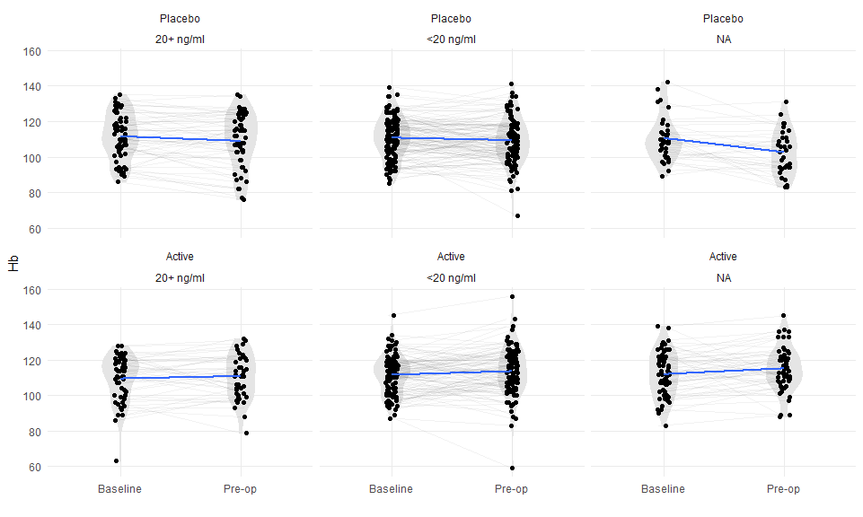

No obvious patterns in the plot above, looking at baseline and pre-op Hb in low vs not-low hepcidin and by study arm (top row placebo arm, bottom row active arm).

|  | TDL pre-op Hb g/L |  |  |
| --- | --- | --- | --- |
| Predictors | Estimates | CI | p |
| (Intercept) | 108.52 | 106.20 – 110.84 | **<0.001** |
| group: Active | 3.54 | 1.22 – 5.85 | **0.003** |
| hepc bl low: <20 ng/ml | 0.86 | -1.64 – 3.36 | 0.498 |
| mc(tdl hb bl) | 0.75 | 0.65 – 0.85 | **<0.001** |
| Observations | 308 |  |  |
| R<sup>2</sup> / R<sup>2</sup> adjusted | 0.428 / 0.422 |  |  |

Low hepcidin (vs not low) was not associated with baseline adjusted pre-op Hb levels (p for effect = 0.5).

|  | TDL pre-op Hb g/L |  |  |
| --- | --- | --- | --- |
| Predictors | Estimates | CI | p |
| (Intercept) | 109.02 | 106.24 – 111.81 | **<0.001** |
| group: Active | 2.40 | -1.78 – 6.59 | 0.260 |
| hepc bl low: <20 ng/ml | 0.13 | -3.23 – 3.49 | 0.940 |
| mc(tdl hb bl) | 0.75 | 0.65 – 0.85 | **<0.001** |
| groupActive:hepc_bl_low<20 ng/ml | 1.64 | -3.39 – 6.67 | 0.523 |
| Observations | 308 |  |  |
| R<sup>2</sup> / R<sup>2</sup> adjusted | 0.429 / 0.421 |  |  |

There was no interaction between low hepcidin and treatment arm with respect to baseline adjusted pre-op Hb values (p interaction = 0.52).

# Associations between EPO, hepcidin and hemoglobin.

Here we will just relate the change in EPO and hepcidin (baseline to pre-op) to corresponding changes in Hb, adjusted for trial arm.

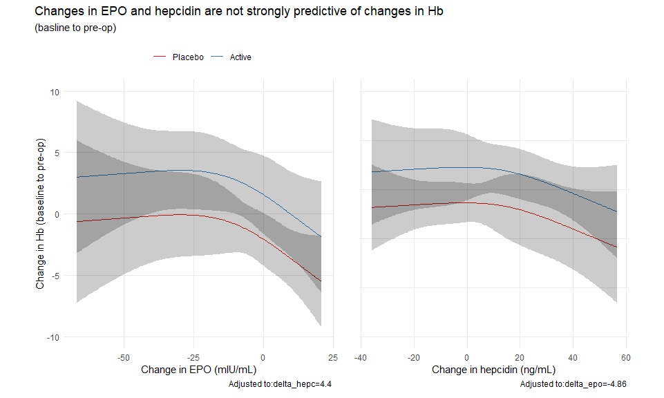

These plots show the model-adjusted relationships between changes in EPO and hepcidin with changes in Hb (baseline to pre-op). The EPO and hepcidin effects are adjusted for one another, as well as for study arm. Potential non-linear effects were accommodated with restricted cubic splines. **Essentially what we see is that there is little or no relationship between changes in EPO or hepcidin with changes in Hb**. This is confirmed by the tests of these associations below.

```
##                 Analysis of Variance          Response: tdl_hb_change
##
##  Factor          d.f. Partial SS MS        F    P
##  group             1    470.4898 470.48978 4.18 0.0419
##  delta_hepc        3    298.9535  99.65117 0.88 0.4494
##   Nonlinear        2    161.1479  80.57395 0.72 0.4899
##  delta_epo         3    618.7157 206.23856 1.83 0.1417
##   Nonlinear        2    280.6539 140.32693 1.25 0.2893
##  TOTAL NONLINEAR   4    487.9426 121.98565 1.08 0.3652
##  REGRESSION        7   1775.1135 253.58765 2.25 0.0305
##  ERROR           276  31087.0696 112.63431
```

# Low hepcidin subgroup effects

## Primary outcome

| names | placebo | active | effect | LRT P |
| --- | --- | --- | --- | --- |
| hepc_preop_low 20+ ng/ml | 21/52 (40%) | 39/126 (31%) | 0.662 (0.34 to 1.29); p = 0.23 | 0.35 |
| hepc_preop_low <20 ng/ml | 34/134 (25%) | 15/57 (26%) | 1.05 (0.52 to 2.13); p = 0.89 | 0.35 |
| hepc_bl_low 20+ ng/ml | 23/63 (37%) | 22/53 (42%) | 1.234 (0.58 to 2.61); p = 0.58 | 0.96 |
| hepc_bl_low <20 ng/ml | 30/135 (22%) | 30/117 (26%) | 1.207 (0.68 to 2.16); p = 0.53 | 0.96 |

Effects are ORs from logistic regression models. LRT P values are for the likelihood ratio test of the overall interaction.

## Second co-primary outcome (number of BTs in the first 30 days)

| names | placebo | active | effect | LRT P |
| --- | --- | --- | --- | --- |
| hepc_preop_low 20+ ng/ml | 0.6 ± 0.8 | 0.5 ± 1 | 0.832 (0.47 to 1.46); p = 0.52 | 0.51 |
| hepc_preop_low <20 ng/ml | 0.4 ± 0.7 | 0.4 ± 0.9 | 1.105 (0.59 to 2.09); p = 0.76 | 0.51 |
| hepc_bl_low 20+ ng/ml | 0.6 ± 0.9 | 0.6 ± 1 | 1.136 (0.63 to 2.05); p = 0.67 | 0.88 |
| hepc_bl_low <20 ng/ml | 0.4 ± 0.9 | 0.4 ± 0.9 | 1.06 (0.57 to 1.96); p = 0.85 | 0.88 |

Effects are IRRs from a quasipossion model. LRT P values are for the likelihood ratio test of the overall interaction.

## Length of hospital stay

| names | placebo | active | effect | LRT P |
| --- | --- | --- | --- | --- |
| hepc_preop_low 20+ ng/ml | 0.6 ± 0.8 | 0.5 ± 1 | 1.043 (0.85 to 1.28); p = 0.68 | 0.70 |
| hepc_preop_low <20 ng/ml | 0.4 ± 0.7 | 0.4 ± 0.9 | 1.106 (0.89 to 1.37); p = 0.36 | 0.70 |
| hepc_bl_low 20+ ng/ml | 0.6 ± 0.9 | 0.6 ± 1 | 1.131 (0.89 to 1.44); p = 0.32 | 0.73 |
| hepc_bl_low <20 ng/ml | 0.4 ± 0.9 | 0.4 ± 0.9 | 1.072 (0.9 to 1.27); p = 0.43 | 0.73 |

Effects are ratios of geometric means from log-linear models. LRT P values are for the likelihood ratio test of the overall interaction.

## Length of ITU stay

Modeled with quasi-Poisson regression.

| names | placebo | active | effect | LRT P |
| --- | --- | --- | --- | --- |
| hepc_preop_low 20+ ng/ml | 0.6 ± 0.8 | 0.5 ± 1 | 1.579 (0.98 to 2.55); p = 0.06 | 1.00 |
| hepc_preop_low <20 ng/ml | 0.4 ± 0.7 | 0.4 ± 0.9 | 1.581 (1.01 to 2.48); p = 0.05 | 1.00 |
| hepc_bl_low 20+ ng/ml | 0.6 ± 0.9 | 0.6 ± 1 | 1.151 (0.68 to 1.95); p = 0.6 | 0.53 |
| hepc_bl_low <20 ng/ml | 0.4 ± 0.9 | 0.4 ± 0.9 | 1.436 (0.97 to 2.13); p = 0.07 | 0.53 |

Effects are IRRs from a quasipossion model. LRT P values are for the likelihood ratio test of the overall interaction.

### Postoperative complications (grade 3+)

| names | placebo | active | effect | LRT P |
| --- | --- | --- | --- | --- |
| hepc_preop_low 20+ ng/ml | 8/50 (16%) | 12/125 (10%) | 0.558 (0.21 to 1.46); p = 0.23 | 0.09 |
| hepc_preop_low <20 ng/ml | 11/133 (8%) | 8/57 (14%) | 1.811 (0.69 to 4.77); p = 0.23 | 0.09 |
| hepc_bl_low 20+ ng/ml | 4/57 (7%) | 8/51 (16%) | 2.465 (0.7 to 8.74); p = 0.16 | 0.06 |
| hepc_bl_low <20 ng/ml | 16/130 (12%) | 8/112 (7%) | 0.548 (0.23 to 1.33); p = 0.19 | 0.06 |

Effects are ORs from logistic regression models. LRT P values are for the likelihood ratio test of the overall interaction.

# End matter

```
##
## System: Windows 10 x64 build 18363
## Nodename: DESKTOP-JKQ7LTN, User: Darren
## Total Memory: 16168 MB
##
## R version 4.0.3 (2020-10-10)
## x86_64-w64-mingw32/x64 (64-bit)
##
## Loaded Packages:
##  broom (0.7.1), patchwork (1.0.1), ggfortify (0.4.11), sjPlot (2.8.5), rms (6.0-1), SparseM (1.78), Hmisc (4.4-1), Formula (1.2-3), survival (3.2-7), lattice (0.20-41), knitr (1.30), viridis (0.5.1), viridisLite (0.3.0), forcats (0.5.0), stringr (1.4.0), dplyr (1.0.2), purrr (0.3.4), readr (1.4.0…
```